# Introduction to Data Visualisation and Distributions

```r
library(dslabs)
library(ggplot2)
library(tidyverse)
```

```r
data(murders)
str(murders)
```

```
'data.frame':   51 obs. of  5 variables:
 $ state     : chr  "Alabama" "Alaska" "Arizona" "Arkansas" ...
 $ abb       : chr  "AL" "AK" "AZ" "AR" ...
 $ region    : Factor w/ 4 levels "Northeast","South",..: 2 4 4 2 4 4 1 2 2 2 ...
 $ population: num  4779736 710231 6392017 2915918 37253956 ...
 $ total     : num  135 19 232 93 1257 ...
```

```r
head(murders)
```

|  | state | abb | region | population | total |
| --- | --- | --- | --- | --- | --- |
| 1 | Alabama | AL | South | 4779736 | 135 |
| 2 | Alaska | AK | West | 710231 | 19 |
| 3 | Arizona | AZ | West | 6392017 | 232 |
| 4 | Arkansas | AR | South | 2915918 | 93 |
| 5 | California | CA | West | 37253956 | 1257 |
| 6 | Colorado | CO | West | 5029196 | 65 |

- Data types:
  - Categorical
    - Ordinal
    - Non-ordinal
  - Numeric
    - Discrete
    - Continuous

```r
data(heights)
str(heights)
```

```
'data.frame':   1050 obs. of  2 variables:
 $ sex   : Factor w/ 2 levels "Female","Male": 2 2 2 2 2 1 1 1 1 2 ...
 $ height: num  75 70 68 74 61 65 66 62 66 67 ...
```

```r
summary(heights)
```

```
     sex          height
 Female:238   Min.   :50.00
 Male  :812   1st Qu.:66.00
              Median :68.50
              Mean   :68.32
              3rd Qu.:71.00
              Max.   :82.68
```

```r
tapply(heights$height, heights$sex, summary)
```

```
$Female
   Min. 1st Qu.  Median    Mean 3rd Qu.    Max.
  51.00   63.00   64.98   64.94   67.00   79.00

$Male
   Min. 1st Qu.  Median    Mean 3rd Qu.    Max.
  50.00   67.00   69.00   69.31   72.00   82.68
```

## Distributions

A distribution is a function or description that shows the possible values of a variable and how often those values occur.

For categorical variables, the distribution describes the proportions of each category.

A frequency table is the simplest way to show a categorical distribution. Use prop.table() to convert a table of counts to a frequency table. Barplots display the distribution of categorical variables and are a way to visualize the information in frequency tables.

For continuous numerical data, reporting the frequency of each unique entry is not an effective summary as many or most values are unique. Instead, a distribution function is required.

The cumulative distribution function (CDF) is a function that reports the proportion of data below a value 𝑎 for all values of 𝑎: 𝐹(𝑎)=Pr(𝑥≤𝑎).

The proportion of observations between any two values 𝑎 and 𝑏 can be computed from the CDF as 𝐹(𝑏)−𝐹(𝑎).

A histogram divides data into non-overlapping bins of the same size and plots the counts of number of values that fall in that interval.

If a distribution is not normal, it cannot be summarized with only the mean and standard deviation. Provide a histogram, smooth density or boxplot instead.

A plot can force us to see unexpected results that make us question the quality or implications of our data.

```r
prop.table(table(heights$sex))
```

```
   Female      Male
0.2266667 0.7733333
```

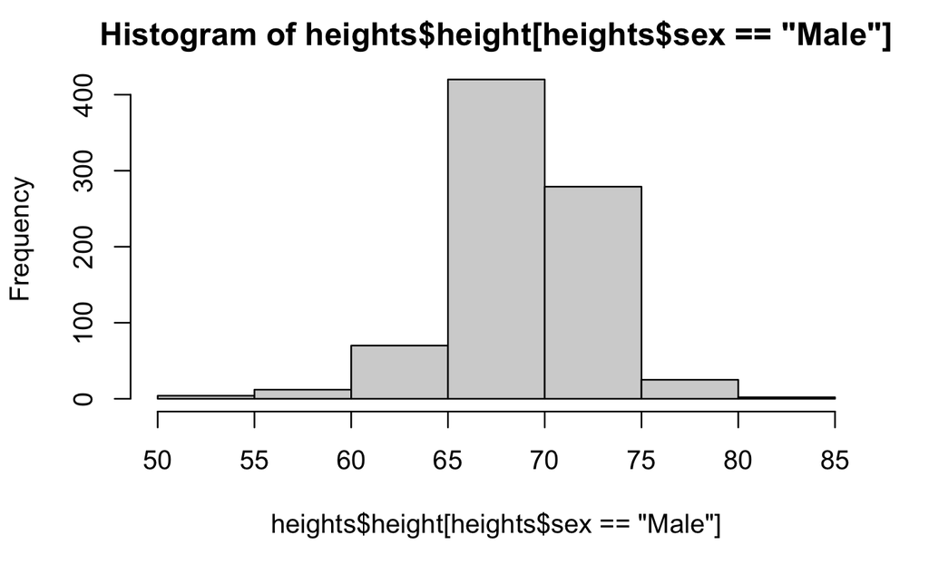

```r
hist(heights$height[heights$sex == "Male"])
```

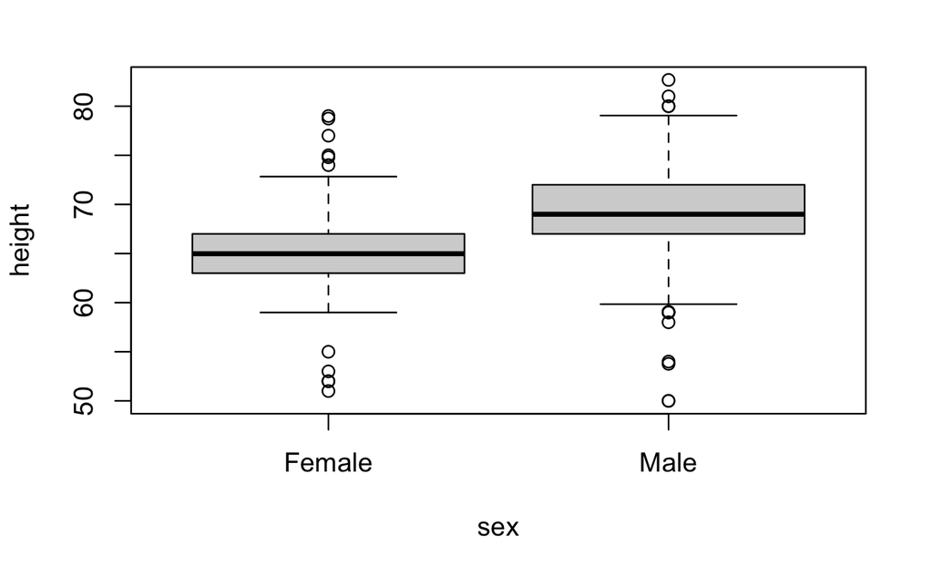

```r
boxplot(height ~ sex, data = heights)
```

#### Cumulative Distribution Function

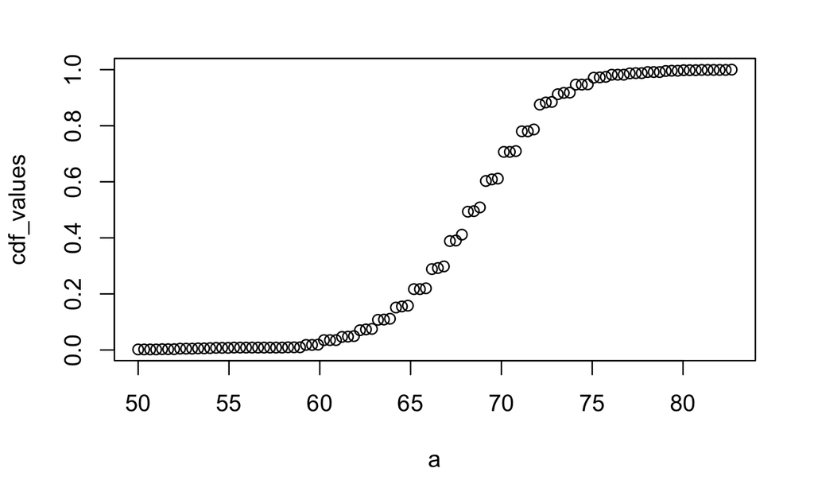

```r
my_data <- heights$height
a <- seq(min(my_data), max(my_data), length = 100)    # define range of values spanning the dataset
cdf_function <- function(x) {    # computes prob. for a single value
    mean(my_data <= x)
}
cdf_values <- sapply(a, cdf_function)
plot(a, cdf_values)
```

#### Smooth Density Plot

Smooth density plots can be thought of as histograms where the bin width is extremely or infinitely small. The smoothing function makes estimates of the true continuous trend of the data given the available sample of data points.

The degree of smoothness can be controlled by an argument in the plotting function. (We will learn functions for plotting later.)

While the histogram is an assumption-free summary, the smooth density plot is shaped by assumptions and choices you make as a data analyst. The y-axis is scaled so that the area under the density curve sums to 1. This means that interpreting values on the y-axis is not straightforward. To determine the proportion of data in between two values, compute the area under the smooth density curve in the region between those values.

An advantage of smooth densities over histograms is that densities are easier to compare visually

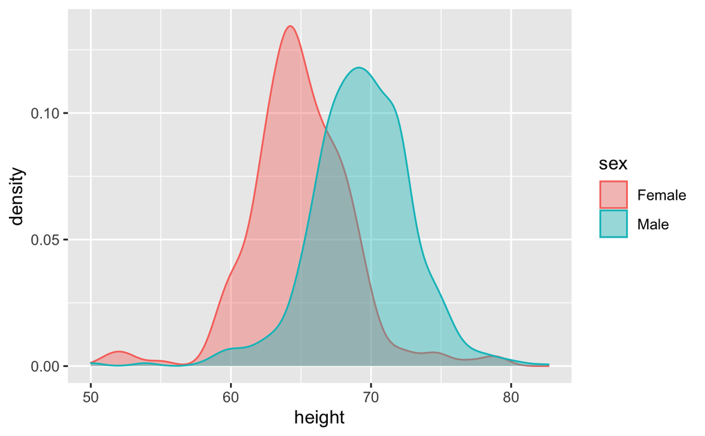

```r
ggplot(heights, aes(height, color = sex, fill = sex)) +
  geom_density(alpha = 0.4)
```

#### Normal Distribution

The normal distribution: - Is centered around one value, the mean - Is symmetric around the mean - Is defined completely by its mean (𝜇) and standard deviation ( 𝜎 ) - Always has the same proportion of observations within a given distance of the mean (for example, 95% within 2 𝜎)

The standard deviation is the average distance between a value and the mean value.

Calculate the mean using the mean() function.

Calculate the standard deviation using the sd() function or manually.

Standard units describe how many standard deviations a value is away from the mean. The z-score, or number of standard deviations an observation 𝑥 is away from the mean 𝜇:

```
𝑍=𝑥−𝜇𝜎
```

Compute standard units with the scale() function.

Important: to calculate the proportion of values that meet a certain condition, use the mean() function on a logical vector. Because TRUE is converted to 1 and FALSE is converted to 0, taking the mean of this vector yields the proportion of TRUE.

The normal distribution is mathematically defined by the following formula for any mean 𝜇 and standard deviation 𝜎:

```
Pr(𝑎<𝑥<𝑏)=∫𝑏𝑎12𝜋√𝜎𝑒−12(𝑥−𝜇𝜎)2𝑑𝑥
```

```r
# define x as vector of male heights
data(heights)
index <- heights$sex=="Male"
x <- heights$height[index]

# calculate the mean and standard deviation manually
average <- sum(x)/length(x)
SD <- sqrt(sum((x - average)^2)/length(x))

# built-in mean and sd functions - note that the audio and printed values disagree
average <- mean(x)
SD <- sd(x)
c(average = average, SD = SD)
```

```
  average        SD
69.314755  3.611024
```

```r
# calculate standard units
z <- scale(x)

# calculate proportion of values within 2 SD of mean
mean(abs(z) < 2)
```

```
[1] 0.9495074
```

### Standard Units and Z-Scores

#### Standard Units

For data that are approximately normal, standard units describe the number of standard deviations an observation is from the mean. Standard units are denoted by the variable 𝑧 and are also known as z-scores.

For any value 𝑥 from a normal distribution with mean 𝜇 and standard deviation 𝜎, the value in standard units is:

𝑧=𝑥−𝜇𝜎

Standard units are useful for many reasons. Note that the formula for the normal distribution is simplified by substituting 𝑧 in the exponent:

Pr(𝑎<𝑥<𝑏)=∫𝑏𝑎12𝜋√𝜎𝑒−12𝑧2𝑑𝑥

When 𝑧=0, the normal distribution is at a maximum, the mean 𝜇. The function is defined to be symmetric around 𝑧=0.

The normal distribution of z-scores is called the standard normal distribution and is defined by 𝜇=0 and 𝜎=1.

Z-scores are useful to quickly evaluate whether an observation is average or extreme. Z-scores near 0 are average. Z-scores above 2 or below -2 are significantly above or below the mean, and z-scores above 3 or below -3 are extremely rare.

We will learn more about benchmark z-score values and their corresponding probabilities below.

```r
# The scale function converts a vector of approximately normally distributed values into z-scores.

z <- scale(x)

# You can compute the proportion of observations that are within 2 standard
# deviations of the mean like this:

mean(abs(z) < 2)
```

```
[1] 0.9495074
```

The normal distribution is associated with the 68-95-99.7 rule. This rule describes the probability of observing events within a certain number of standard deviations of the mean. This image shows the density plot for the normal distribution. It has shaded ranges corresponding to values within 1, 2 or 3 standard deviations of the mean. It lists that observations fall within these ranges 68.3%, 95.4%, and 99.7% of the time respectively.

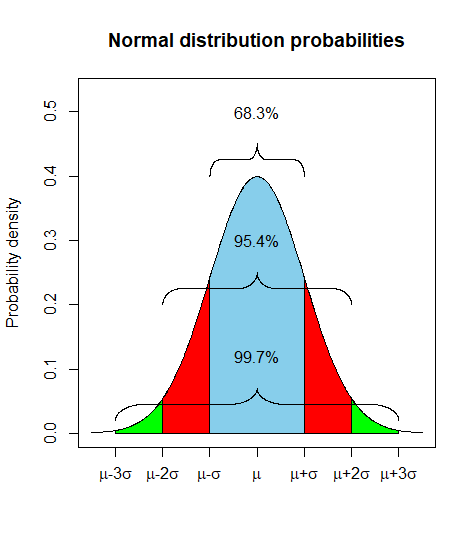

The probability distribution function for the normal distribution is defined such that:

- About 68% of observations will be within one standard deviation of the mean (𝜇±𝜎). In standard units, this is equivalent to a z-score of ∣𝑧∣≤1. This density plot of the normal distribution has values within 1 standard deviation of the mean shaded in and notes that 68.3% of observations fall in this range.

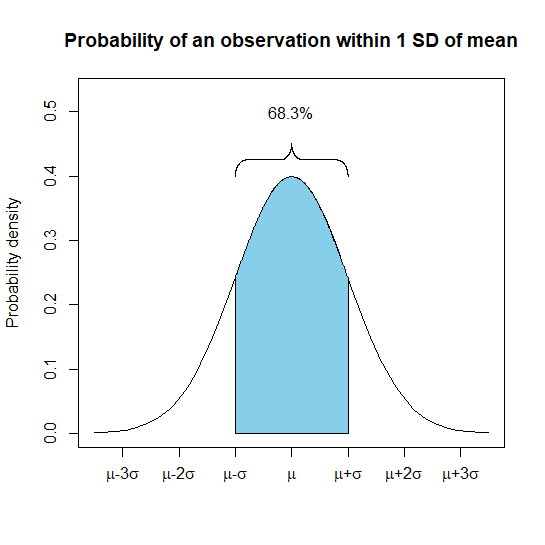

- About 95% of observations will be within two standard deviations of the mean (𝜇±2𝜎). In standard units, this is equivalent to a z-score of ∣𝑧∣≤2.This density plot of the normal distribution has values within 2 standard deviations of the mean shaded in and notes that 95.4% of observations fall in this range.

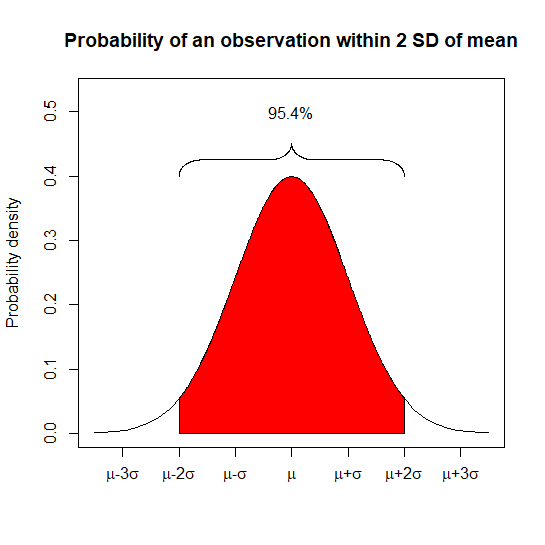

- About 99.7% of observations will be within three standard deviations of the mean (𝜇±3𝜎). In standard units, this is equivalent to a z-score of ∣𝑧∣≤3. This density plot of the normal distribution has values within 3 standard deviations of the mean shaded in and notes that 99.7% of observations fall in this range.

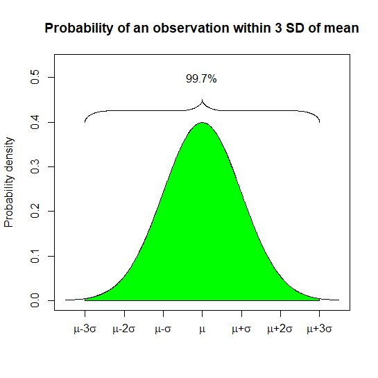

##### The Normal CDF and `pnorm`

The normal distribution has a mathematically defined CDF which can be computed in R with the function pnorm().

`pnorm(a, avg, s)` gives the value of the cumulative distribution function 𝐹(𝑎) for the normal distribution defined by average avg and standard deviation s.

We say that a random quantity is normally distributed with average avg and standard deviation s if the approximation pnorm(a, avg, s) holds for all values of a.

If we are willing to use the normal approximation for height, we can estimate the distribution simply from the mean and standard deviation of our values.

If we treat the height data as discrete rather than categorical, we see that the data are not very useful because integer values are more common than expected due to rounding. This is called discretization.

With rounded data, the normal approximation is particularly useful when computing probabilities of intervals of length 1 that include exactly one integer.

```r
data(heights)
x <- heights %>% filter(sex=="Male") %>% pull(height)

# We can estimate the probability that a male is taller than 70.5 inches with:
1 - pnorm(70.5, mean(x), sd(x))
```

```
[1] 0.371369
```

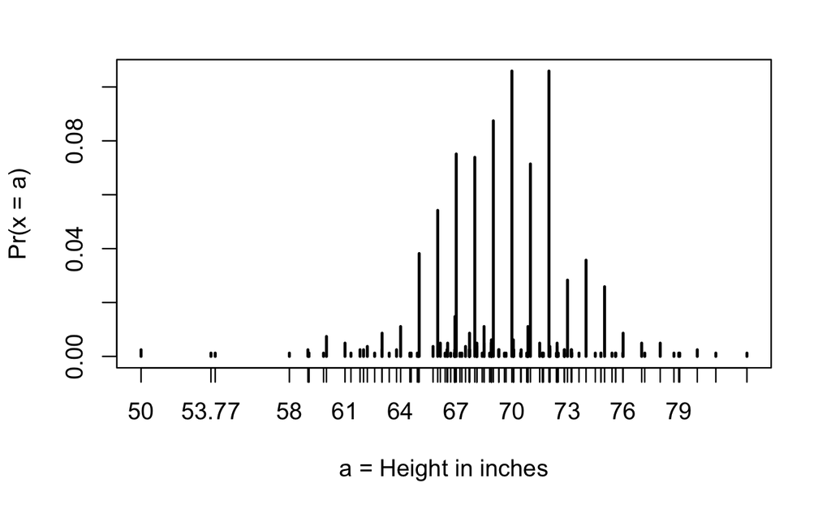

```r
# plot distribution of exact heights in data
plot(prop.table(table(x)), xlab = "a = Height in inches", ylab = "Pr(x = a)")
```

```r
# probabilities in actual data over length 1 ranges containing an integer
mean(x <= 68.5) - mean(x <= 67.5)
```

```
[1] 0.114532
```

```r
mean(x <= 69.5) - mean(x <= 68.5)
```

```
[1] 0.1194581
```

```r
mean(x <= 70.5) - mean(x <= 69.5)
```

```
[1] 0.1219212
```

```r
# probabilities in normal approximation match well
pnorm(68.5, mean(x), sd(x)) - pnorm(67.5, mean(x), sd(x))
```

```
[1] 0.1031077
```

```r
pnorm(69.5, mean(x), sd(x)) - pnorm(68.5, mean(x), sd(x))
```

```
[1] 0.1097121
```

```r
pnorm(70.5, mean(x), sd(x)) - pnorm(69.5, mean(x), sd(x))
```

```
[1] 0.1081743
```

```r
# probabilities in actual data over other ranges don't match normal approx as well
mean(x <= 70.9) - mean(x <= 70.1)
```

```
[1] 0.02216749
```

```r
pnorm(70.9, mean(x), sd(x)) - pnorm(70.1, mean(x), sd(x))
```

```
[1] 0.08359562
```

## Quantiles, Percentiles, and Boxplots

*Quantiles* are cutoff points that divide a dataset into intervals with set probabilities. The 𝑞th quantile is the value at which 𝑞% of the observations are equal to or less than that value.

Given a dataset data and desired quantile q, you can find the qth quantile of data with:

`quantile(data,q)`

*Percentiles* Percentiles are the quantiles that divide a dataset into 100 intervals each with 1% probability. You can determine all percentiles of a dataset data like this:

```
p <- seq(0.01, 0.99, 0.01)
quantile(data, p)
```

*Quartiles* Quartiles divide a dataset into 4 parts each with 25% probability. They are equal to the 25th, 50th and 75th percentiles. The 25th percentile is also known as the 1st quartile, the 50th percentile is also known as the median, and the 75th percentile is also known as the 3rd quartile.

The `summary()` function returns the minimum, quartiles and maximum of a vector.

```r
# Load the heights dataset from the dslabs package:
library(dslabs)
data(heights)

# Use summary() on the heights$height variable to find the quartiles:
summary(heights$height)
```

```
   Min. 1st Qu.  Median    Mean 3rd Qu.    Max.
  50.00   66.00   68.50   68.32   71.00   82.68
```

```r
# Find the percentiles of heights$height:
p <- seq(0.01, 0.99, 0.01)
percentiles <- quantile(heights$height, p)

# Confirm that the 25th and 75th percentiles match the 1st and 3rd quartiles.
# Note that quantile() returns a named vector. You can access the 25th and 75th
# percentiles like this (adapt the code for other percentile values):
percentiles[names(percentiles) == "25%"]
```

```
25%
 66
```

```r
percentiles[names(percentiles) == "75%"]
```

```
75%
 71
```

### Quantiles

#### `qnorm`

The qnorm() function gives the theoretical value of a quantile with probability p of observing a value equal to or less than that quantile value given a normal distribution with mean mu and standard deviation sigma:

`qnorm(p, mu, sigma)`

By default, mu=0 and sigma=1. Therefore, calling qnorm() with no arguments gives quantiles for the standard normal distribution.

`qnorm(p)`

Recall that quantiles are defined such that p is the probability of a random observation less than or equal to the quantile.

##### Relation to `pnorm`

The `pnorm()` function gives the probability that a value from a standard normal distribution will be less than or equal to a z-score value z. Consider:

`pnorm(-1.96) ≈0.025`

The result of pnorm() is the quantile. Note that:

`qnorm(0.025) ≈−1.96`

`qnorm()` and `pnorm()` are inverse functions:

`pnorm(qnorm(0.025)) =0.025`

##### Theoretical quantiles

You can use qnorm() to determine the theoretical quantiles of a dataset: that is, the theoretical value of quantiles assuming that a dataset follows a normal distribution. Run the qnorm() function with the desired probabilities p, mean mu and standard deviation sigma.

Suppose male heights follow a normal distribution with a mean of 69 inches and standard deviation of 3 inches. The theoretical quantiles are:

```r
p <- seq(0.01, 0.99, 0.01)
theoretical_quantiles <- qnorm(p, 69, 3)
theoretical_quantiles
```

```
 [1] 62.02096 62.83875 63.35762 63.74794 64.06544 64.33568 64.57263
 [8] 64.78479 64.97773 65.15535 65.32042 65.47504 65.62083 65.75904
[15] 65.89070 66.01663 66.13750 66.25390 66.36631 66.47514 66.58074
[22] 66.68342 66.78346 66.88109 66.97653 67.06996 67.16156 67.25148
[29] 67.33985 67.42680 67.51245 67.59690 67.68026 67.76261 67.84404
[36] 67.92462 68.00444 68.08356 68.16204 68.23996 68.31737 68.39432
[43] 68.47088 68.54709 68.62302 68.69870 68.77419 68.84954 68.92479
[50] 69.00000 69.07521 69.15046 69.22581 69.30130 69.37698 69.45291
[57] 69.52912 69.60568 69.68263 69.76004 69.83796 69.91644 69.99556
[64] 70.07538 70.15596 70.23739 70.31974 70.40310 70.48755 70.57320
[71] 70.66015 70.74852 70.83844 70.93004 71.02347 71.11891 71.21654
[78] 71.31658 71.41926 71.52486 71.63369 71.74610 71.86250 71.98337
[85] 72.10930 72.24096 72.37917 72.52496 72.67958 72.84465 73.02227
[92] 73.21521 73.42737 73.66432 73.93456 74.25206 74.64238 75.16125
[99] 75.97904
```

Theoretical quantiles can be compared to sample quantiles determined with the quantile function in order to evaluate whether the sample follows a normal distribution.

#### Quantile-Quantile (QQ) Plots

Quantile-quantile plots, or QQ-plots, are used to check whether distributions are well-approximated by a normal distribution.

Given a proportion 𝑝, the quantile 𝑞 is the value such that the proportion of values in the data below 𝑞 is 𝑝.

In a QQ-plot, the sample quantiles in the observed data are compared to the theoretical quantiles expected from the normal distribution. If the data are well-approximated by the normal distribution, then the points on the QQ-plot will fall near the identity line (sample = theoretical).

Calculate sample quantiles (observed quantiles) using the quantile() function.

Calculate theoretical quantiles with the `qnorm()` function. `qnorm()` will calculate quantiles for the standard normal distribution (𝜇=0,𝜎=1) by default, but it can calculate quantiles for any normal distribution given `mean()` and `sd()` arguments. We will learn more about `qnorm()` in the probability course.

Note that we will learn alternate ways to make QQ-plots with less code later in the series.

```r
# define x and z
library(tidyverse)
library(dslabs)
data(heights)
index <- heights$sex=="Male"
x <- heights$height[index]
z <- scale(x)

# proportion of data below 69.5
mean(x <= 69.5)
```

```
[1] 0.5147783
```

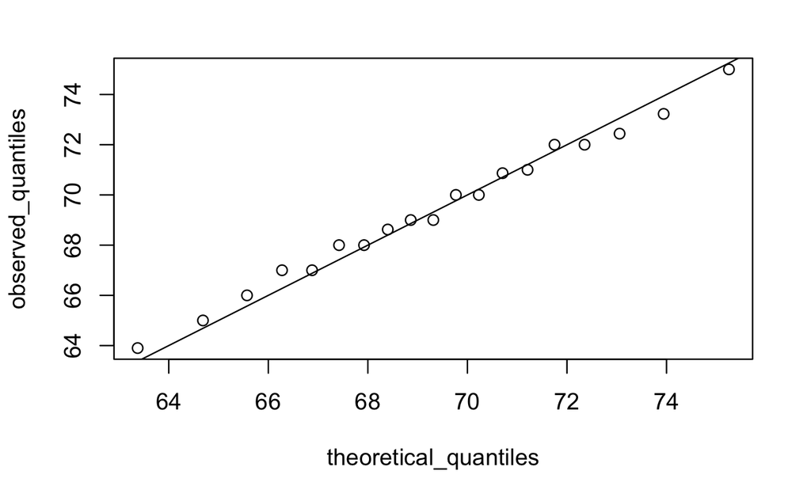

```r
# calculate observed and theoretical quantiles
p <- seq(0.05, 0.95, 0.05)
observed_quantiles <- quantile(x, p)
theoretical_quantiles <- qnorm(p, mean = mean(x), sd = sd(x))

# make QQ-plot
plot(theoretical_quantiles, observed_quantiles)
abline(0,1)
```

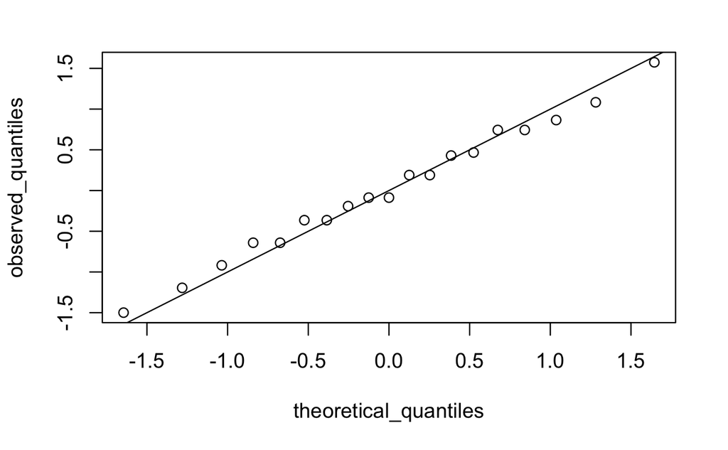

```r
# make QQ-plot with scaled values
observed_quantiles <- quantile(z, p)
theoretical_quantiles <- qnorm(p)
plot(theoretical_quantiles, observed_quantiles)
abline(0,1)
```

### Percentiles

Percentiles are the quantiles obtained when defining 𝑝 as 0.01,0.02,…,0.99. They summarize the values at which a certain percent of the observations are equal to or less than that value.

The 50th percentile is also known as the *median*.

The *quartiles* are the 25th, 50th and 75th percentiles.

### Boxplots

When data do not follow a normal distribution and cannot be succinctly summarized by only the mean and standard deviation, an alternative is to report a five-number summary: range (ignoring outliers) and the quartiles (25th, 50th, 75th percentile).

In a boxplot, the box is defined by the 25th and 75th percentiles and the median is a horizontal line through the box. The whiskers show the range excluding outliers, and outliers are plotted separately as individual points.

The interquartile range is the distance between the 25th and 75th percentiles.

Boxplots are particularly useful when comparing multiple distributions.